# Forks

Julian Frattini

2024-10-15

This notebook visualizes the effect of **forks** (also called: common causes) in causal inference. Forks are one of the most common sources for spurious associations in causal inference and, hence, particularly dangerous to the validity of drawn conclusions.

## Context

Let us consider a hypothetical example of a phenomenon. Assume we are interested in whether the (voluntary) student attendance to lecture affects final grade.

### Causal Assumptions

Formally speaking, we are interested in the effect of attendance `a` on the students’ performance `p`. We also assume that both variables are influenced by motivation `m`: more motivated students attend class more often and more motivated students also exhibit a higher performance. We can visualize the causal assumptions as follows.

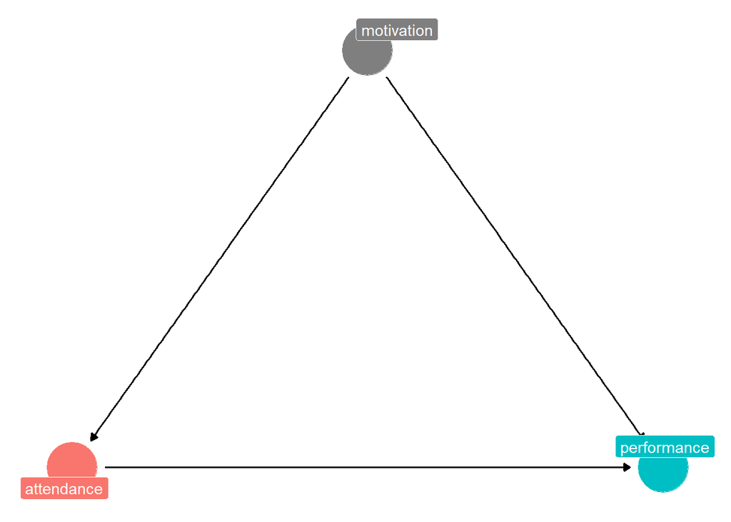

```r
dag <- dagify(
  p ~ a + m,
  a ~ m,
  exposure = "a", outcome = "p",

  labels = c(a = "attendance", p = "performance", m = "motivation"),
  coords = list(x = c(a = 0, p = 2, m = 1),
                y = c(a = 0, p = 0, m = 1))
)

ggdag_status(dag, use_labels = "label", text = FALSE) +
  guides(fill = "none", color = "none") +
  theme_dag()
```

This example might not reflect reality, it serves solely for demonstration purposes. In reality, many more variables could affect the phenomenon.

### Simulation

Let us simulate data, i.e., produce a data set in which we know the strength of the effects in our causal assumptions. Particularly, let us assume that

- motivated students are more likely to attend class,
- motivated students are strongly more likely to pass a class, but
- attending the class reduces the likelihood of passing the class.

The last effect might be due to the class not being good and rather confusing than educating students. We reflect this effect by simulating the value of performance as $p \sim \mathcal{N}(-0.3a+0.9m, 0.5)$, meaning that attending the class slightly lowers performance by -0.3, but motivated students perform 0.9 units better.

```r
n <- 500 # number of simulated units, i.e., students

d <- data.frame(
  m = rbinom(n, 1, 0.5) # simulated values of m
) %>% mutate(
  a = rbinom(n, 1, 0.3+0.5*m) # simulated values of a, which depend on the values of m
  ) %>% mutate(
    p = rnorm(n, -0.3*a + 0.9*m, 0.5)
  )
```

## Analysis

Ignoring our insight into how data `d` was actually produced (i.e., how strong the causal effects actually are), we can attempt an analysis to recover those effects.

### Naive Analysis

If we just focus on the causal relationship of interest, $a \rightarrow p$, we might be tempted to run a simple linear regression of $p \sim a$.

```r
m1 <- lm(
  formula = p ~ a,
  data = d
)

summary(m1)
```

```
##
## Call:
## lm(formula = p ~ a, data = d)
##
## Residuals:
##     Min      1Q  Median      3Q     Max
## -1.7928 -0.4817 -0.0030  0.4486  2.0569
##
## Coefficients:
##             Estimate Std. Error t value Pr(>|t|)
## (Intercept)  0.21357    0.04471   4.777 2.35e-06 ***
## a            0.10994    0.06084   1.807   0.0714 .
## ---
## Signif. codes:  0 '***' 0.001 '**' 0.01 '*' 0.05 '.' 0.1 ' ' 1
##
## Residual standard error: 0.6781 on 498 degrees of freedom
## Multiple R-squared:  0.006513,   Adjusted R-squared:  0.004518
## F-statistic: 3.265 on 1 and 498 DF,  p-value: 0.07139
```

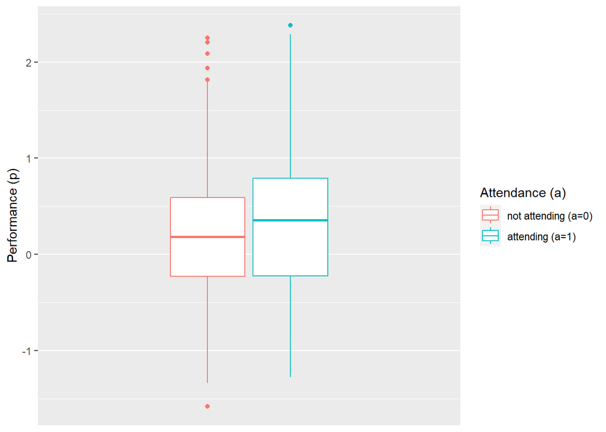

```r
ggplot(data = d,
       mapping = aes(y = p, color = as.factor(a))) +
  geom_boxplot() +
  labs(y = "Performance (p)",
       color = "Attendance (a)") +
  scale_color_discrete(labels=c("not attending (a=0)", "attending (a=1)")) +
  scale_x_discrete(labels = NULL, breaks = NULL)
```

### Proper Analysis

Knowing how the data was generated should raise concerns: we fixed the effect of attendance on performance to be negative, so why does the naive model suggest it is positive? This is because the data generation process contains the fork `m` which opens a non-causal backdoor path $a \leftarrow m \rightarrow p$. Backdoor paths must be closed, e.g., by adjusting for a fork. In our case, we can simply include the fork `m` in our regression model.

```r
m2 <- lm(
  formula = p ~ a + m,
  data = d
)

summary(m2)
```

```
##
## Call:
## lm(formula = p ~ a + m, data = d)
##
## Residuals:
##      Min       1Q   Median       3Q      Max
## -1.88432 -0.35036 -0.00349  0.32783  1.75278
##
## Coefficients:
##             Estimate Std. Error t value Pr(>|t|)
## (Intercept)  0.01139    0.03621   0.315    0.753
## a           -0.37312    0.05378  -6.937 1.25e-11 ***
## m            0.98937    0.05372  18.416  < 2e-16 ***
## ---
## Signif. codes:  0 '***' 0.001 '**' 0.01 '*' 0.05 '.' 0.1 ' ' 1
##
## Residual standard error: 0.5233 on 497 degrees of freedom
## Multiple R-squared:  0.4095, Adjusted R-squared:  0.4071
## F-statistic: 172.3 on 2 and 497 DF,  p-value: < 2.2e-16
```

Now, the model correctly identifies a negative effect of `a` on `p` and also the positive effect of `m` on `p`. Visualizing the data correctly (i.e., also reflecting the influence of `m`) shows this difference.

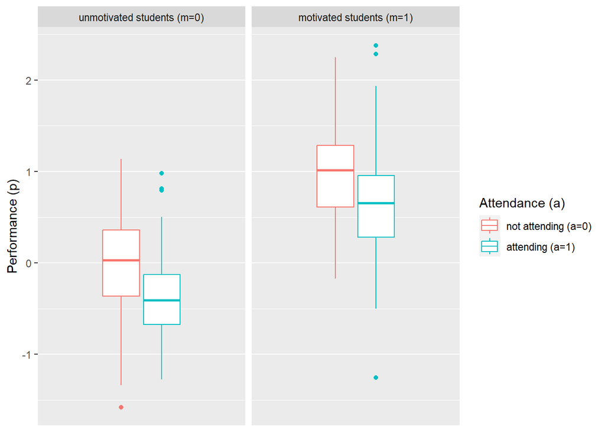

```r
motivation_names <- c(
  `0`="unmotivated students (m=0)",
  `1`="motivated students (m=1)"
)

ggplot(data = d,
       mapping = aes(y = p, color = as.factor(a))) +
  geom_boxplot() +
  facet_wrap(~as.factor(m), ncol=2, labeller = as_labeller(motivation_names)) +
  labs(y = "Performance (p)",
       color = "Attendance (a)") +
  scale_color_discrete(labels=c("not attending (a=0)", "attending (a=1)")) +
  scale_x_discrete(labels = NULL, breaks = NULL)
```

The faceted visualization shows that attendance lowers the performance, but motivation greatly increases it.